# Lab3

Luna Catalan

2024-04-17

### Assignment Lab 3:

Due next week: April 23 at 11:59PM

For this assignment you’ll use the article data you downloaded from Nexis Uni in Week 2.

```r
library(quanteda)
library(tm)
library(topicmodels)
library(ldatuning)
library(tidyverse)
library(tidytext)
library(reshape2)
library(LDAvis) #visualization
library("tsne") #matrix decomposition
```

1. Create a corpus from your articles.

```r
dir <- here::here("class", "data", "News_gw_policy")
#news_tbl <- read_csv(here::here("class", "data", "News_gw_policy", "news.csv"))
news_files <- list.files(pattern = ".docx",
                         path = dir,
                         full.names = TRUE, recursive = TRUE, ignore.case = TRUE)
news_files

# take files list and read them into LNT object
dat <- LexisNexisTools::lnt_read(news_files, convert_date = FALSE, remove_cover = FALSE)

# reference 'slot' using @
meta_df <- dat@meta
articles_df <- dat@articles
paragraphs_df <- dat@paragraphs


# create tibble with these columns
dat2 <- tibble(Date = meta_df$Date,
               Headline = meta_df$Headline,
               id = articles_df$ID,
               text = articles_df$Article)

text_clean <- dat2 %>%

  # remove the urls from the text
  separate_wider_delim(text,
                       delim = "Delivered by Newstex)   ",
                       names = c("delete", "text"),
                       too_few = "align_end") %>%
  select(-delete) %>%

  # remove the notes at the end
  separate_wider_delim(text,
                       delim = "The views expressed in any and all content distributed by Newstex",
                       names = c("text", "delete"),
                       too_few = "align_start") %>%
  select(-delete) %>%

  # remove any of the urls that start with https
  mutate(text = gsub(" ?(f|ht)tp(s?)://(.*)[.][a-z]+", "",
                     text))

corpus <- corpus(x = text_clean,
                 text_field = "text") # column to extract text
```

2. Clean the data as appropriate.
- remove stop words
- remove punctuation, numbers, and url
- make all the words lowercase
- remove infrequent words

```r
tokens <- tokens(corpus,
               remove_punct = T,
               remove_numbers = T,
               remove_url = T)

# create stop word dictionary
add_stops <- stopwords(kind = quanteda_options(("language_stopwords")))

# remove stop words
tok1 <- tokens_select(tokens,
                     pattern = add_stops, # remove
                     selection = "remove")

dfm1 <- dfm(tok1,
            tolower = T) # make words lowercase

# remove the really infrequent words from document feature matrix
dfm2 <- dfm_trim(dfm1,
                 min_docfreq = 2) # must occur at least 2 times to stay

# if the sum across the row is greater than 0 we will keep it
sel_ind <- slam::row_sums(dfm2) > 0
dfm <- dfm2[sel_ind, ]
```

3. Run three models (i.e. with 3 values of k) and select the overall best value for k (the number of topics) - include some justification for your selection: theory, FindTopicsNumber() optimization metrics, interpretability, LDAvis. Select the best single value of k.

```r
set.seed(123)

results <- FindTopicsNumber(dfm,
                            topics = seq(from = 2,
                                         to = 20,
                                         by = 1),
                            metrics = c("CaoJuan2009", "Deveaud2014"), # what to measure how good the number of topics
                            method = "Gibbs",
                            verbose = T)
```

```
## fit models... done.
## calculate metrics:
##   CaoJuan2009... done.
##   Deveaud2014... done.
```

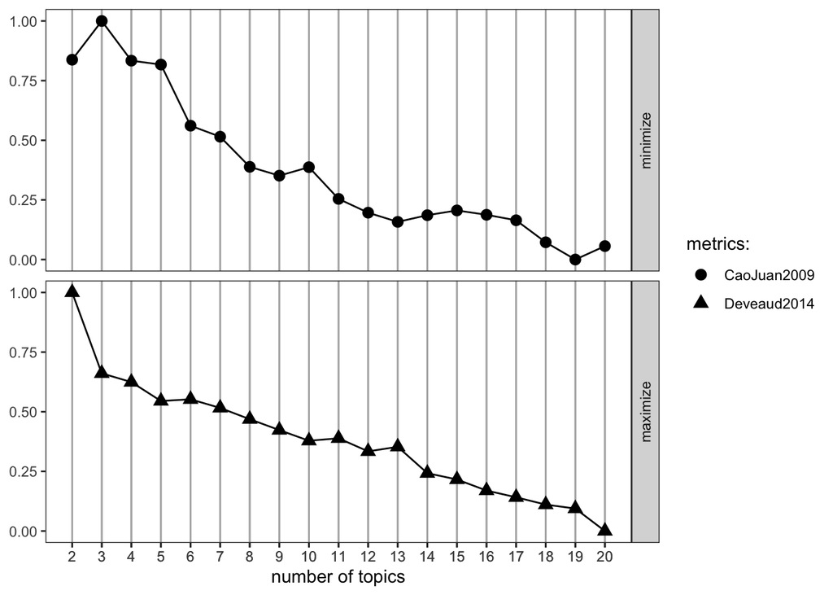

```r
FindTopicsNumber_plot(results)
```

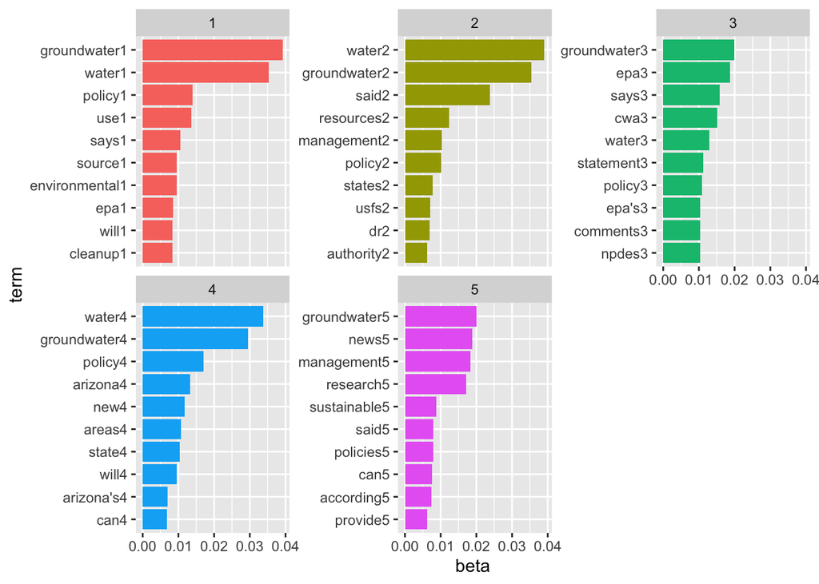

```r
k <- 5

topicModel_k <- LDA(dfm, # matrix
                     k, # number of topics
                     method = "Gibbs", # the upsampling process
                     control = list(iter = 1000,
                                    verbose = 25))

tmResults <- posterior(topicModel_k)
terms(topicModel_k, 10)

beta <- tmResults$terms
# distribution of topics across articles
theta <- tmResults$topics
vocab <- colnames(beta)

topics <- tidy(topicModel_k, matrix = "beta")

top_terms <- topics %>%
  group_by(topic) %>%
  top_n(10, beta) %>%
  ungroup() %>%
  arrange(topic, -beta)

top_terms %>%
  mutate(term= reorder_within(term, beta, topic, sep = "")) %>%
  ggplot(aes(x = term, y = beta, fill = factor(topic))) +
  geom_col(show.legend = F) +
  facet_wrap(~topic, scales = "free_y") +
  scale_x_reordered() +
  coord_flip()
```

```r
svd_tsne <- function(x) tsne(svd(x)$u)
json <- createJSON(
  phi = tmResults$terms,
  theta = tmResults$topics,
  doc.length = rowSums(dfm),
  vocab = colnames(dfm),
  term.frequency = colSums(dfm),
  mds.method = svd_tsne,
  plot.opts = list(xlab="", ylab="")
)
```

```
## sigma summary: Min. : 33554432 |1st Qu. : 33554432 |Median : 33554432 |Mean : 33554432 |3rd Qu. : 33554432 |Max. : 33554432 |
```

[output not shown]

[output not shown]

[output not shown]

[output not shown]

[output not shown]

[output not shown]

[output not shown]

[output not shown]

[output not shown]

[output not shown]

```r
serVis(json)
```

4. Plot the top terms in each topic and the distribution of topics across a sample of the documents (constrained by what looks good in the plot).

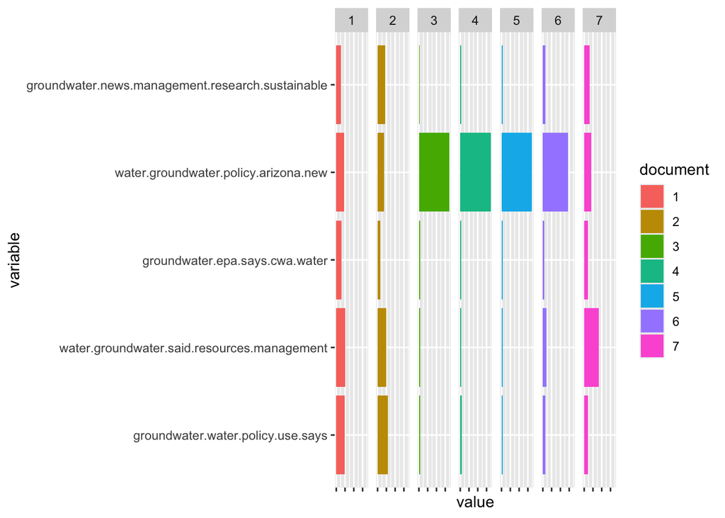

```r
topic_words <- terms(topicModel_k, 5) # top 5 words for each topic

# create topic names with first 5 words of the topics
topic_names <- apply(topic_words, 2,
                     paste, collapse = " ")

# distribution of topics across documents - select the first 5 documents
example_ids <- c(1:7)
n <- length(example_ids)

# get topic proportions from example documents
example_props <- theta[example_ids,] # pull index ids
colnames(example_props) <- topic_names

#combine example topics with identifiers and melt to plotting form
viz_df <- melt(cbind(data.frame(example_props),
                     document = factor(1:n),
                     variable.names = "topic",
                     id.vars = "document"))

ggplot(data = viz_df,
       aes(x = variable,
           y = value,
           fill = document),
       ylab = "proportion") +
  geom_bar(stat = "identity") +
  coord_flip() +
  facet_wrap(~document, ncol = n) +
  theme(axis.text.x = element_blank())
```

5. Take a stab at interpreting the resulting topics. What are the key themes discussed in the articles in your data base?

The resulting topics have to do with management policy, research into groundwater management, eps’s involvement with groundwater, the clean water act (cwa), and policy in arizona. The key themes are management policy involving the epa and the arizona government. Thsi makes sense considering the state of groundwater in Arizona and its water issues.